# Descriptive Statistic

Arash Hatamirad, ahatamirad@gmail.com

9/1/2021

Cars.csv will be used for Exercise. The variables in the data are included below in the table. The variables in the data set are the following attributes of cars in the year 2004:

 Make – the auto manufacturer  
 Model – name of the vehicle  
 Type – SUV, sedan, sports, truck, or wagon  
 Origin – continent of the manufacturer; Europe, Asia, or USA  
 Invoice – price (dollars) that the manufacturer sends to the dealer upon delivery of the car  
 Horsepower – amount of the car’s power  
 MPG_City – miles per gallon (fuel efficiency) during city driving  
 MPG_Highway – miles per gallon during highway driving  
 Wheelbase – distance (inches) between the centers of the front and rear wheels  
 Length – distance (inches) from the nose to the tail of the car

## Exercise: Descriptive Statistics

#### Question (a):

- Create a combined mpg variable called MPG_Combo which combines 60% of the MPG_City and 40% of the MPG_Highway. Obtain a box plot for MPG_Combo and comment on what the plot tells us about fuel efficiencies.

#### Answer -:

```r
# Read the CSV file
file.cars=read.csv("CARS.csv")
```

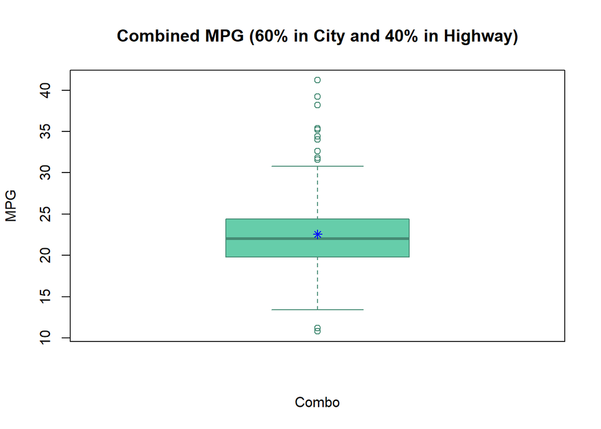

```r
# Make new MPG_Combo variable
MPG_Combo <- 0.6*file.cars$MPG_City +0.4*file.cars$MPG_Highway

#Add MPG_Combo variable to the end of tabale
file.cars.mpg_combo <- cbind(file.cars,MPG_Combo)



#Draw Box plot for the MPG_Combo variable and trim box plot
boxplot(file.cars.mpg_combo$MPG_Combo,main="Combined MPG (60% in City and 40% in Highway)",xlab="Combo",ylab="MPG",col = "aquamarine3",border ="aquamarine4")

#Point the mean value with a blue asterisk sign
points(mean(file.cars.mpg_combo$MPG_Combo,na.rm = TRUE),col="blue",pch=8)
```

##### Comment:

According to the above box plot, in combined mode:  
- The “Mean” and “Median” values are almost close, then distribution might be normal.  
- 50% of cars (Q1 to Q3) can travel 20 to 25 MPG.  
- There are some outliers above the maximum and below the minimum  
- To ensure about the normality, we must use QQ-Plot or perform a Quantitative test  
- Minimum is around 14 MPG and maximum is around 32 MPG

#### Question (b):

- Obtain box plots for MPG_Combo by Type and comment on any differences you notice between the different vehicle types combined fuel efficiency.

#### Answer -:

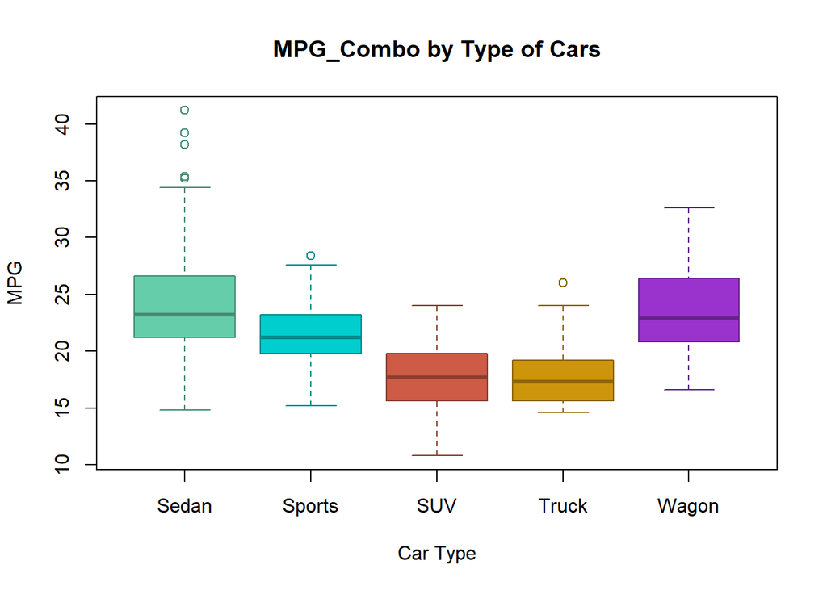

```r
#Draw box plot for MPG_Combo by Type
boxplot(file.cars.mpg_combo$MPG_Combo~file.cars.mpg_combo$Type,xlab = "Car Type",ylab = "MPG",main="MPG_Combo by Type of Cars",border=(c("aquamarine4","cyan4","coral4","darkgoldenrod4","darkorchid4")),horizontal = FALSE,col=(c("aquamarine3","cyan3","coral3","darkgoldenrod3","darkorchid3")))
```

##### Comment:

According to the above box plot:  
- Wagon and Sedan travel maximum efficiency  
- Truck and SUV are about same and have minimum efficiency  
- Sports is little more efficiency than Truck and SUV but less than Sedan and Wagon  
- Sedan has more outliers on maximum efficiency side

#### Question (c):

- Obtain basic descriptive statistics for Horsepower for all vehicles. Comment on any general features and statistics of the data. Use visual and quantitative methods to comment on whether an assumption of Normality would be reasonable for Horsepower variable.

#### Answer -:

Basic descriptive statistics comprise:

```r
# Calculate descriptive stattistics:
a=psych:: describe(file.cars$Horsepower)
knitr::kable(a,format = "markdown",caption = "Statistical Values",align = "c")
```

Statistical Values

|  | vars | n | mean | sd | median | trimmed | mad | min | max | range | skew | kurtosis | se |
| --- | --- | --- | --- | --- | --- | --- | --- | --- | --- | --- | --- | --- | --- |
| X1 | 1 | 425 | 216.76 | 71.31586 | 210 | 211.5367 | 66.717 | 100 | 500 | 400 | 0.9528091 | 1.546674 | 3.459327 |

##### Comment:

According to above table:  
- Mean > Median and Skewness > 0, thus we guess we will have a right long tail.  
- To ensure, we will use visual method.

##### Visual method

###### Histogram Plot / Box Plot / QQ Plot

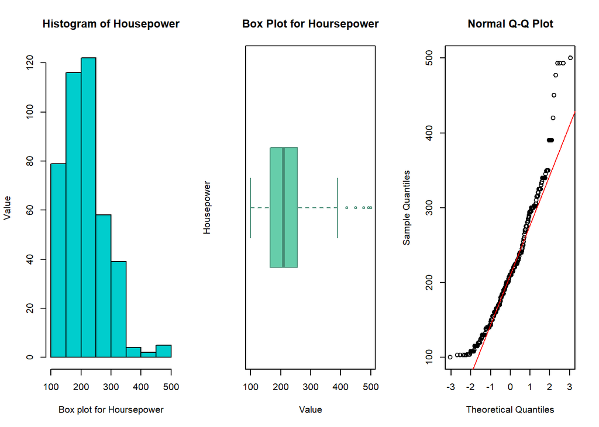

```r
# Prepare the sheet for 1X3 diagrams
par(mfrow=c(1,3))

# Plot the Histogram
hist(file.cars$Horsepower,col="cyan3",xlab = "Box plot for Hoursepower",ylab = "Value",main = "Histogram of Housepower")

# draw Box Plot
boxplot(file.cars$Horsepower,main="Box Plot for Hoursepower",xlab="Value",ylab="Housepower",col = "aquamarine3",border ="aquamarine4",horizontal = TRUE)
points(mean(file.cars$Horsepower,na.rm = TRUE),col="blue",pch=8)

# draw QQ Plot
qqnorm.var=qqnorm(file.cars$Horsepower)
qqline(file.cars$Horsepower,col="red")
```

#### Comments:

As histogram diagram, we can see the right skewness and right long tail.  
As box plot diagram, we can see more outliers at the right side.  
As QQ plot, we can see majority near the red line but some other outliers, to ensure about the normality, we must use the “Shapiro-Wilk” test as below.

##### Quantitative method

###### Shapiro-Wilk Test

```r
# calculate Shapiro value
shapiro.results=shapiro.test(file.cars$Horsepower)
print(shapiro.results[2])
```

```
## $p.value
## [1] 2.320249e-11
```

#### Conclusion:

P-Value is very small and less than significant value, hence  
Horsepower data is not follow normal distribution.

#### Question (d):

- Use visual and quantitative methods to comment on whether an assumption of normality would be reasonable for Horsepower variable by Type, especially for Sports, SUV, and Truck (i.e., check normality of Horsepower from Type of i) Sport, ii) SUV, and iii) Truck.

#### Answer -:

#### i) Type=Sport

##### Visual method

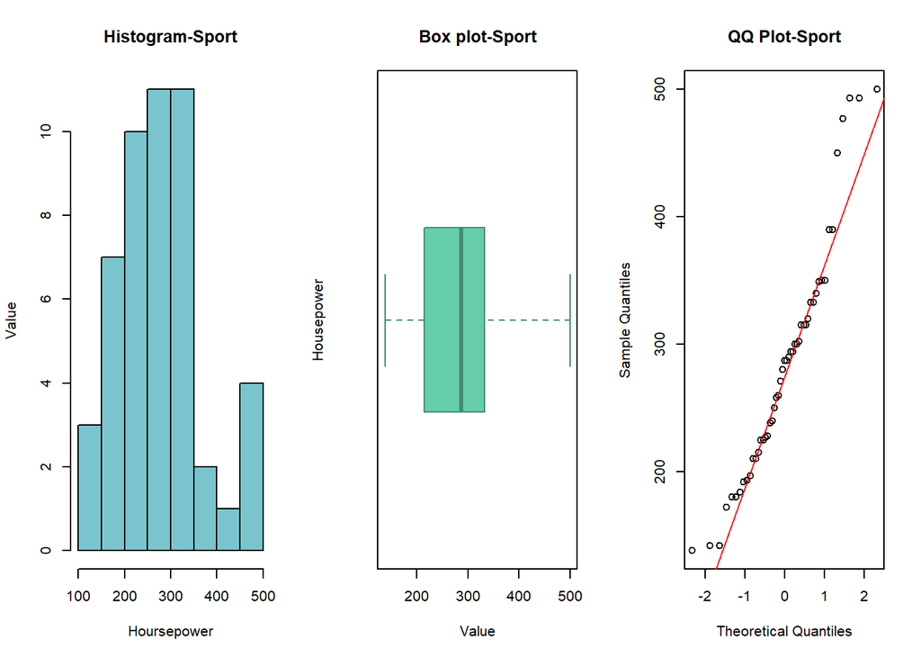

```r
# Prepare the sheet for 1X3 diagrams
par(mfrow=c(1,3))

# Visual diagrams for SPORT cars
file.cars[file.cars$Type=="Sports",]$Horsepower %>%
hist(col="cadetblue3",xlab = "Hoursepower",ylab = "Value",main = "Histogram-Sport")

file.cars[file.cars$Type=="Sports",]$Horsepower %>%
boxplot(main="Box plot-Sport",xlab="Value",ylab="Housepower",col = "aquamarine3",border ="aquamarine4",horizontal = TRUE)
points(mean(file.cars$Horsepower,na.rm = TRUE),col="blue",pch=8)

file.cars[file.cars$Type=="Sports",]$Horsepower %>%
qqnorm(main="QQ Plot-Sport")

file.cars[file.cars$Type=="Sports",]$Horsepower %>%
qqline(col="red")
```

#### Comments:

As the visual method:  
- Histogram and Box plot show a little right skewed and right long tail.  
- QQ plot shows there are a majority of data closed to red line, but there are a lot of points away from the red line.  
Therefor, it may be normal distribution or not, to be ensure, we use the quantitative test (Shapiro-Wilk Test)

##### Shapiro-Wilk Test

- H0: Data follow normal distribution
- H1: Data doesn’t follow normal distribution

```r
# calculate Shapiro value

file.cars[file.cars$Type == "Sports","Horsepower"] %>%
  shapiro.test() %>%
  print()
```

```
##
##  Shapiro-Wilk normality test
##
## data:  .
## W = 0.94276, p-value = 0.01898
```

#### Conclusion:

P-Value < Significant Value (0.05)

P-Value is smaller than significant value, hence  
We have enough evidence to reject the H0 (Null Hypothesis), thus our conclusion is data doesn’t follow normal distribution.

#### ii) Type=SUV

##### Visual method

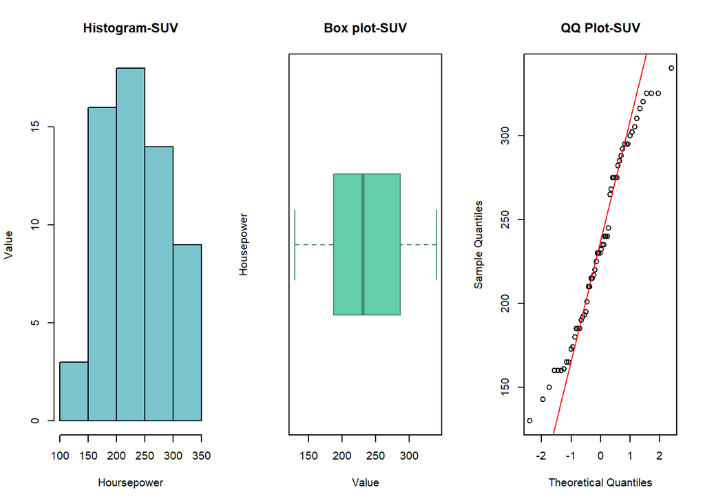

```r
# Prepare the sheet for 1X3 diagrams
par(mfrow=c(1,3))

# Visual diagrams for SUV cars
file.cars[file.cars$Type=="SUV",]$Horsepower %>%
hist(col="cadetblue3",xlab = "Hoursepower",ylab = "Value",main = "Histogram-SUV")

file.cars[file.cars$Type=="SUV",]$Horsepower %>%
boxplot(main="Box plot-SUV",xlab="Value",ylab="Housepower",col = "aquamarine3",border ="aquamarine4",horizontal = TRUE)
points(mean(file.cars$Horsepower,na.rm = TRUE),col="blue",pch=8)

file.cars[file.cars$Type=="SUV",]$Horsepower %>%
qqnorm(main="QQ Plot-SUV")

file.cars[file.cars$Type=="SUV",]$Horsepower %>%
qqline(col="red")
```

##### Shapiro-Wilk Test

- H0: Data follow normal distribution
- H1: Data doesn’t follow normal distribution

```r
# calculate Shapiro value

file.cars[file.cars$Type=="SUV","Horsepower"] %>%
  shapiro.test() %>%
  print()
```

```
##
##  Shapiro-Wilk normality test
##
## data:  .
## W = 0.95945, p-value = 0.04423
```

#### Conclusion:

P-Value < Significant Value (0.05)

P-Value is smaller than significant value, hence  
We have enough evidence to reject the H0 (Null Hypothesis), thus our conclusion is data doesn’t follow normal distribution.

#### iiii) Type=Truck

##### Visual method

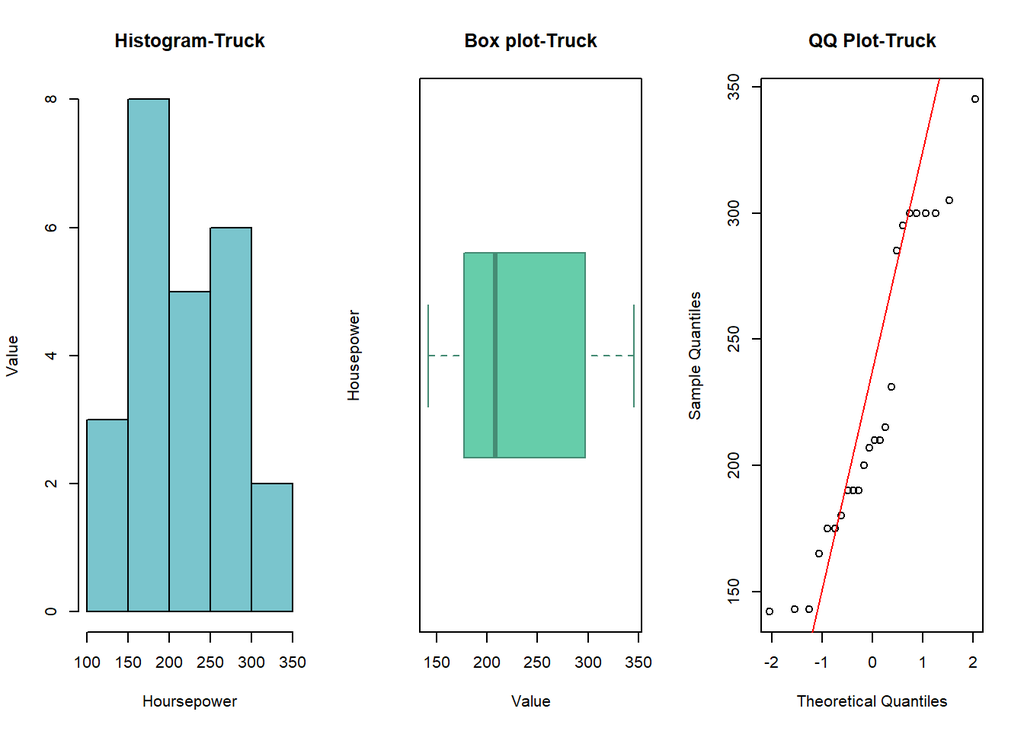

```r
# Prepare the sheet for 1X3 diagrams
par(mfrow=c(1,3))

# Visual diagrams for Truck cars
file.cars[file.cars$Type=="Truck",]$Horsepower %>%
hist(col="cadetblue3",xlab = "Hoursepower",ylab = "Value",main = "Histogram-Truck")

file.cars[file.cars$Type=="Truck",]$Horsepower %>%
boxplot(main="Box plot-Truck",xlab="Value",ylab="Housepower",col = "aquamarine3",border ="aquamarine4",horizontal = TRUE)
points(mean(file.cars$Horsepower,na.rm = TRUE),col="blue",pch=8)

file.cars[file.cars$Type=="Truck",]$Horsepower %>%
qqnorm(main="QQ Plot-Truck")

file.cars[file.cars$Type=="Truck",]$Horsepower %>%
qqline(col="red")
```

#### Comments:

As the visual method:  
- Histogram and Box plot show a data is not normal.  
_ QQ plot shows there are a lot of points with more distance of red line.  
Data looks is not normal distributed, but we will use the quantitatively test (Shapiro-Wilk Test) to ensure.

##### Shapiro-Wilk Test

- H0: Data follow normal distribution
- H1: Data doesn’t follow normal distribution

```r
# calculate Shapiro value

file.cars[file.cars$Type=="Truck","Horsepower"] %>%
  shapiro.test() %>%
  print()
```

```
##
##  Shapiro-Wilk normality test
##
## data:  .
## W = 0.8951, p-value = 0.01697
```

#### Conclusion:

P-Value < Significant Value (0.05)

P-Value is smaller than significant value, then  
We have enough evidence to reject the H0 (NULL Hypothesis), thus our conclusion is data doesn’t follow normal distribution.